# EDA 61 — Exposure Variable Profile: 17 Chronic Condition Flags

Andersen Behavioral Model — Primary Exposure Domain

Author

Analysis Team

Published

May 22, 2026

# Mission

This EDA profiles the 17 chronic-condition exposure variables (`cc_*`) that constitute the primary predictor domain in the Andersen Behavioral Model framework. It directly addresses §2.2 (primary exposure definition) and previews §4.3 (bivariate associations) from the statistical instructions.

**Research Questions:**

1. What is the weighted prevalence of each chronic condition in the employed population?
2. How does each chronic condition relate to the primary outcome (`days_absent_total`) — mean days, median days, and zero-proportion?
3. What is the missing-data pattern across the 17 `cc_*` variables?
4. What is the multimorbidity structure — how many conditions do respondents report, and which condition pairs most frequently co-occur?

Following the dual-file development pattern, all analytical code lives in `analysis/eda-61/eda-61.R`. This document sources those chunks for presentation.

# Definition of Terms

**Chronic condition (`cc_*`)**: A long-term health condition (expected duration ≥6 months) diagnosed by a health professional. Coded as R logical (`TRUE`/`FALSE`). Source: CCHS Canadian Community Health Survey chronic conditions module (CCC).

**Multimorbidity**: The co-occurrence of two or more chronic conditions in the same individual.

**`days_absent_total`**: Primary outcome. Row-wise sum of all 8 LOP component variables, representing total workdays missed in the past 3 months due to health reasons.

**Exposure domain**: In the Andersen Behavioral Model, chronic conditions represent the mechanism through which predisposing, facilitating, and needs factors translate into absenteeism.

# Environment

> Reviews the components of the working environment. Non-technical readers may skip this section.

**Packages used in the current report**

```r
library(magrittr)
library(ggplot2)
library(forcats)
library(stringr)
library(dplyr)
library(tidyr)
library(scales)
library(fs)
requireNamespace("arrow")
```

**Collection of custom functions used in current repository**

```r
base::source("./scripts/common-functions.R")
base::source("./scripts/operational-functions.R")
if (file.exists("./scripts/graphing/graph-presets.R")) {
  base::source("./scripts/graphing/graph-presets.R")
}
```

**Values used throughout the report**

```r
local_root    <- "./analysis/eda-61/"
local_data    <- paste0(local_root, "data-local/")
prints_folder <- paste0(local_root, "prints/")
data_private_derived <- "./data-private/derived/eda-61/"

if (!fs::dir_exists(local_data))           fs::dir_create(local_data)
if (!fs::dir_exists(prints_folder))        fs::dir_create(prints_folder)
if (!fs::dir_exists(data_private_derived)) fs::dir_create(data_private_derived)

path_cchs2_parquet  <- "./data-private/derived/cchs-2-tables"
path_analytical_pq  <- file.path(path_cchs2_parquet, "cchs_analytic.parquet")
weight_col          <- "wts_m_pooled"

# The 17 chronic condition exposure variables (logical flags)
cc_vars <- c(
  "cc_asthma", "cc_fibromyalgia", "cc_arthritis", "cc_back_problems",
  "cc_hypertension", "cc_migraine", "cc_copd", "cc_diabetes",
  "cc_heart_disease", "cc_cancer", "cc_ulcer", "cc_stroke",
  "cc_bowel_disorder", "cc_fatigue_syndrome", "cc_chem_sensitivity",
  "cc_mood_disorder", "cc_anxiety"
)

# Human-readable labels for display
cc_labels <- c(
  "cc_asthma"           = "Asthma",
  "cc_fibromyalgia"     = "Fibromyalgia",
  "cc_arthritis"        = "Arthritis",
  "cc_back_problems"    = "Back problems",
  "cc_hypertension"     = "High blood pressure",
  "cc_migraine"         = "Migraine headaches",
  "cc_copd"             = "COPD",
  "cc_diabetes"         = "Diabetes",
  "cc_heart_disease"    = "Heart disease",
  "cc_cancer"           = "Cancer",
  "cc_ulcer"            = "Stomach/intestinal ulcers",
  "cc_stroke"           = "Stroke effects",
  "cc_bowel_disorder"   = "Bowel disorder",
  "cc_fatigue_syndrome" = "Chronic fatigue syndrome",
  "cc_chem_sensitivity" = "Chemical sensitivity",
  "cc_mood_disorder"    = "Mood disorder",
  "cc_anxiety"          = "Anxiety disorder"
)
```

**Custom functions defined for use in this report**

```r
# No analysis-specific helpers required at this stage.
```

# Data

**Load data from Ellis parquet outputs**

```r
if (!file.exists(path_analytical_pq)) {
  stop("Missing required file: ", path_analytical_pq, call. = FALSE)
}

ds0 <- arrow::read_parquet(path_analytical_pq)

required_cols <- c(
  weight_col, "days_absent_total", "days_absent_chronic",
  "cchs_cycle", "cchs_cycle_f",
  cc_vars
)
missing_required <- setdiff(required_cols, names(ds0))
if (length(missing_required) > 0) {
  stop("Missing required columns in cchs_analytic.parquet: ",
       paste(missing_required, collapse = ", "), call. = FALSE)
}

cat(sprintf("Loaded analytical data: %s rows, %s columns\n",
            format(nrow(ds0), big.mark = ","),
            format(ncol(ds0), big.mark = ",")))
```

```
Loaded analytical data: 63,843 rows, 69 columns
```

## Data Context

For complete data documentation, see the Data Primer.

**Tables and variables used in this analysis**

```r
data_context_tables <- tibble::tibble(
  source_table = "cchs_analytic.parquet",
  location     = path_analytical_pq,
  rows         = nrow(ds0),
  columns      = ncol(ds0),
  usage        = paste(
    "17 chronic-condition logical flags (cc_*),",
    "primary outcome days_absent_total, survey weight wts_m_pooled"
  )
)
print(data_context_tables)
```

```
# A tibble: 1 × 5
  source_table          location                                                  rows columns usage
  <chr>                 <chr>                                                    <int>   <int> <chr>
1 cchs_analytic.parquet ./data-private/derived/cchs-2-tables/cchs_analytic.parq… 63843      69 17 c…
```

**Representative individual with multiple chronic conditions**

```r
# A respondent with multiple chronic conditions — shows the key columns
data_context_person <- ds0 %>%
  select(cchs_cycle_f, !!weight_col, days_absent_total, all_of(cc_vars)) %>%
  mutate(n_conditions = rowSums(across(all_of(cc_vars)), na.rm = TRUE)) %>%
  filter(n_conditions >= 3) %>%
  select(-n_conditions) %>%
  slice_head(n = 2)
print(data_context_person)
```

```
# A tibble: 2 × 20
  cchs_cycle_f wts_m_pooled days_absent_total cc_asthma cc_fibromyalgia cc_arthritis
  <fct>               <dbl>             <dbl> <lgl>     <lgl>           <lgl>
1 2010-2011            208.                 0 FALSE     FALSE           TRUE
2 2010-2011            228.                 0 TRUE      FALSE           FALSE
# ℹ 14 more variables: cc_back_problems <lgl>, cc_hypertension <lgl>, cc_migraine <lgl>,
#   cc_copd <lgl>, cc_diabetes <lgl>, cc_heart_disease <lgl>, cc_cancer <lgl>, cc_ulcer <lgl>,
#   cc_stroke <lgl>, cc_bowel_disorder <lgl>, cc_fatigue_syndrome <lgl>, cc_chem_sensitivity <lgl>,
#   cc_mood_disorder <lgl>, cc_anxiety <lgl>
```

**Prevalence summary of 17 chronic condition variables**

```r
# Prevalence summary for each cc_* variable
data_context_distributions <- ds0 %>%
  summarise(
    across(
      all_of(cc_vars),
      list(
        n_total    = ~ n(),
        n_true     = ~ sum(.x == TRUE, na.rm = TRUE),
        n_false    = ~ sum(.x == FALSE, na.rm = TRUE),
        n_na       = ~ sum(is.na(.x)),
        pct_true   = ~ mean(.x == TRUE, na.rm = TRUE) * 100
      )
    )
  ) %>%
  pivot_longer(
    cols         = everything(),
    names_to     = c("variable", ".value"),
    names_pattern = "^(.+)_(n_total|n_true|n_false|n_na|pct_true)$"
  ) %>%
  mutate(label = cc_labels[variable]) %>%
  arrange(desc(pct_true))
print(data_context_distributions)
```

```
# A tibble: 17 × 7
   variable            n_total n_true n_false  n_na pct_true label
   <chr>                 <int>  <int>   <int> <int>    <dbl> <chr>
 1 cc_back_problems      63843  11524   52274    45   18.1   Back problems
 2 cc_hypertension       63843   8960   54740   143   14.1   High blood pressure
 3 cc_arthritis          63843   8312   55390   141   13.0   Arthritis
 4 cc_migraine           63843   6699   57112    32   10.5   Migraine headaches
 5 cc_asthma             63843   5181   58623    39    8.12  Asthma
 6 cc_mood_disorder      63843   4232   59548    63    6.64  Mood disorder
 7 cc_anxiety            63843   3485   60285    73    5.46  Anxiety disorder
 8 cc_diabetes           63843   3043   60771    29    4.77  Diabetes
 9 cc_bowel_disorder     63843   2950   60826    67    4.63  Bowel disorder
10 cc_copd               63843   1201   41487 21155    2.81  COPD
11 cc_heart_disease      63843   1776   61973    94    2.79  Heart disease
12 cc_chem_sensitivity   63843   1670   62081    92    2.62  Chemical sensitivity
13 cc_ulcer              63843   1441   62309    93    2.26  Stomach/intestinal ulcers
14 cc_fibromyalgia       63843    732   63051    60    1.15  Fibromyalgia
15 cc_cancer             63843    706   63088    49    1.11  Cancer
16 cc_fatigue_syndrome   63843    551   63226    66    0.864 Chronic fatigue syndrome
17 cc_stroke             63843    248   63569    26    0.389 Stroke effects
```

**Reshape to long-form for analysis**

```r
# Long-form chronic condition dataset — shared ancestor for G1, G2, G4 families
ds_cc_long <- ds0 %>%
  select(
    cchs_cycle, cchs_cycle_f, !!weight_col,
    days_absent_total, days_absent_chronic,
    all_of(cc_vars)
  ) %>%
  pivot_longer(
    cols      = all_of(cc_vars),
    names_to  = "condition",
    values_to = "has_condition"
  ) %>%
  mutate(
    condition_label = cc_labels[condition],
    condition_label = factor(condition_label, levels = cc_labels)
  )

# Multimorbidity count per respondent
ds_multimorbidity <- ds0 %>%
  select(cchs_cycle, cchs_cycle_f, !!weight_col,
         days_absent_total, days_absent_chronic, all_of(cc_vars)) %>%
  mutate(
    n_conditions = rowSums(across(all_of(cc_vars)), na.rm = TRUE)
  )
```

**Data overview**

```r
cat(sprintf("Long-form dataset: %s rows\n", format(nrow(ds_cc_long), big.mark = ",")))
```

```
Long-form dataset: 1,085,331 rows
```

**Data overview**

```r
cat(sprintf("Conditions per respondent — range: [%d, %d], mean: %.1f\n",
            min(ds_multimorbidity$n_conditions),
            max(ds_multimorbidity$n_conditions),
            mean(ds_multimorbidity$n_conditions)))
```

```
Conditions per respondent — range: [0, 12], mean: 1.0
```

**Data overview**

```r
# ==============================================================================
# G1 FAMILY — Condition Prevalence
# Research question: What is the weighted prevalence of each chronic condition?
# g1  : unweighted prevalence (horizontal bar chart)
# g11 : weighted prevalence (horizontal bar chart)
# g12 : weighted prevalence stratified by CCHS cycle
# ==============================================================================
```

# Analysis

## Graph Family G1: Condition Prevalence

**Prepare prevalence summaries**

```r
g1_data <- ds_cc_long %>%
  group_by(condition, condition_label) %>%
  summarise(
    n_total       = n(),
    n_with        = sum(has_condition == TRUE, na.rm = TRUE),
    pct_unweighted = mean(has_condition == TRUE, na.rm = TRUE) * 100,
    pct_weighted   = weighted.mean(has_condition == TRUE, w = .data[[weight_col]], na.rm = TRUE) * 100,
    .groups = "drop"
  ) %>%
  arrange(desc(pct_weighted))
```

**Unweighted prevalence of chronic conditions**

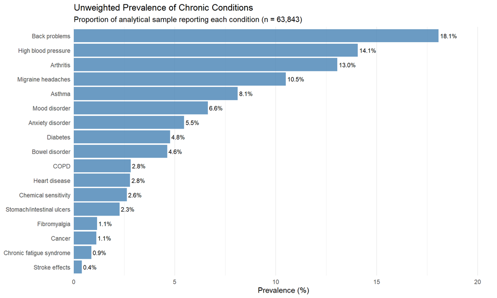

Unweighted prevalence of 17 chronic conditions in the analytical sample

```r
g1_prevalence_unweighted <- g1_data %>%
  ggplot(aes(x = pct_unweighted, y = fct_reorder(condition_label, pct_unweighted))) +
  geom_col(fill = "#4682B4", alpha = 0.8) +
  geom_text(aes(label = sprintf("%.1f%%", pct_unweighted)),
            hjust = -0.1, size = 3) +
  scale_x_continuous(expand = expansion(mult = c(0, 0.15))) +
  labs(
    title    = "Unweighted Prevalence of Chronic Conditions",
    subtitle = "Proportion of analytical sample reporting each condition (n = 63,843)",
    x = "Prevalence (%)",
    y = NULL
  ) +
  theme_minimal(base_size = 11) +
  theme(panel.grid.major.y = element_blank())
print(g1_prevalence_unweighted)
```

**Unweighted prevalence of chronic conditions**

```r
ggsave(paste0(prints_folder, "g1_prevalence_unweighted.png"),
       g1_prevalence_unweighted, width = 8.5, height = 5.5, dpi = 300)
```

**Weighted prevalence of chronic conditions**

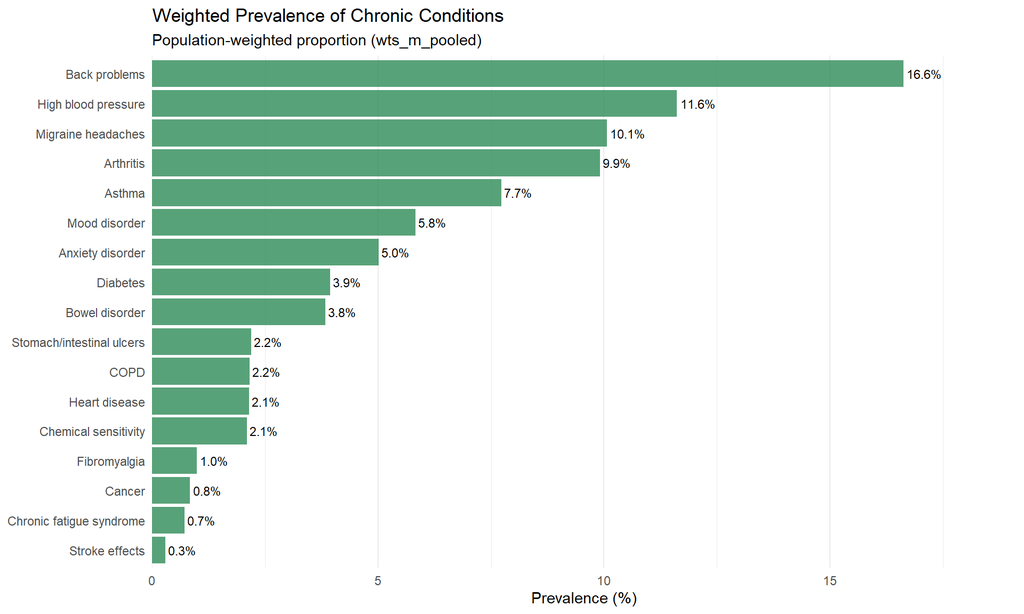

Population-weighted prevalence using wts_m_pooled

```r
g11_prevalence_weighted <- g1_data %>%
  ggplot(aes(x = pct_weighted, y = fct_reorder(condition_label, pct_weighted))) +
  geom_col(fill = "#2E8B57", alpha = 0.8) +
  geom_text(aes(label = sprintf("%.1f%%", pct_weighted)),
            hjust = -0.1, size = 3) +
  scale_x_continuous(expand = expansion(mult = c(0, 0.15))) +
  labs(
    title    = "Weighted Prevalence of Chronic Conditions",
    subtitle = "Population-weighted proportion (wts_m_pooled)",
    x = "Prevalence (%)",
    y = NULL
  ) +
  theme_minimal(base_size = 11) +
  theme(panel.grid.major.y = element_blank())
print(g11_prevalence_weighted)
```

**Weighted prevalence of chronic conditions**

```r
ggsave(paste0(prints_folder, "g11_prevalence_weighted.png"),
       g11_prevalence_weighted, width = 8.5, height = 5.5, dpi = 300)
```

**Weighted prevalence by CCHS cycle**

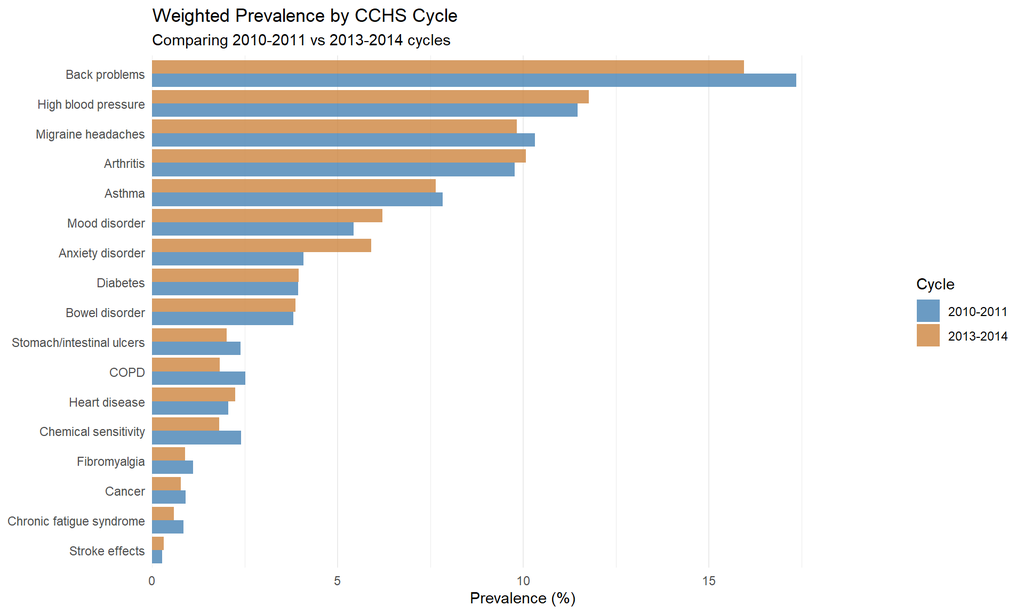

Condition prevalence comparison between 2010-2011 and 2013-2014 cycles

```r
g12_data <- ds_cc_long %>%
  group_by(condition, condition_label, cchs_cycle_f) %>%
  summarise(
    pct_weighted = weighted.mean(has_condition == TRUE, w = .data[[weight_col]], na.rm = TRUE) * 100,
    .groups = "drop"
  )

g12_prevalence_by_cycle <- g12_data %>%
  ggplot(aes(x = pct_weighted, y = fct_reorder(condition_label, pct_weighted),
             fill = cchs_cycle_f)) +
  geom_col(position = "dodge", alpha = 0.8) +
  scale_x_continuous(expand = expansion(mult = c(0, 0.15))) +
  scale_fill_manual(values = c("2010-2011" = "#4682B4", "2013-2014" = "#CD853F")) +
  labs(
    title    = "Weighted Prevalence by CCHS Cycle",
    subtitle = "Comparing 2010-2011 vs 2013-2014 cycles",
    x = "Prevalence (%)",
    y = NULL,
    fill = "Cycle"
  ) +
  theme_minimal(base_size = 11) +
  theme(panel.grid.major.y = element_blank())
print(g12_prevalence_by_cycle)
```

**Weighted prevalence by CCHS cycle**

```r
ggsave(paste0(prints_folder, "g12_prevalence_by_cycle.png"),
       g12_prevalence_by_cycle, width = 8.5, height = 5.5, dpi = 300)


# ==============================================================================
# G1a FAMILY — COPD Age-Gated Prevalence
# Context: The COPD question (CCC_091) was administered only to respondents
#   aged 35+ in the CCHS. Younger respondents have NA on cc_copd because they
#   were never asked the question — NOT because data is missing.
#   Marc-André Blanchette (2026-05-15) recommended showing an age-gated
#   alternative that imputes FALSE for respondents below the threshold and
#   recalculates prevalence within the target age group only.
#
# DHHGAGE code mapping: code 8 = 35-39 yrs → codes 8-15 represent 35-75.
# g1a  : COPD prevalence with age-gating vs naive (full-sample)
# g1a1 : All 17 conditions — prevalence restricted to 35+ subsample
# ==============================================================================
```

## Graph Family G1a: COPD Age-Gated Prevalence

**Prepare COPD age-gated comparison data**

```r
# Age threshold: DHHGAGE code 8 = 35-39 years (first group >= 35)
COPD_AGE_THRESHOLD <- 8L

# Respondents aged 35+ (eligible for the COPD question)
ds0_age35plus <- ds0 %>% filter(dhhgage >= COPD_AGE_THRESHOLD)
n_age35plus <- nrow(ds0_age35plus)

# Comparison data: COPD prevalence full-sample (naive) vs age-gated
copd_naive <- ds0 %>%

  summarise(
    pct_weighted = weighted.mean(cc_copd == TRUE, w = .data[[weight_col]], na.rm = TRUE) * 100,
    n_valid = sum(!is.na(cc_copd)),
    n_na    = sum(is.na(cc_copd))
  ) %>%
  mutate(approach = "Full sample (N = 63,843)\nNA excluded from denominator")

copd_agegated <- ds0_age35plus %>%
  mutate(cc_copd_gated = coalesce(cc_copd, FALSE)) %>%
  summarise(
    pct_weighted = weighted.mean(cc_copd_gated == TRUE, w = .data[[weight_col]], na.rm = TRUE) * 100,
    n_valid = n(),
    n_na    = 0L
  ) %>%
  mutate(approach = sprintf("Age-gated 35+ (n = %s)\nNA imputed as FALSE", format(n_age35plus, big.mark = ",")))

g1a_comparison <- bind_rows(copd_naive, copd_agegated)

# All 17 conditions restricted to 35+ subsample
g1a1_data <- ds0_age35plus %>%
  select(all_of(cc_vars), !!weight_col) %>%
  pivot_longer(cols = all_of(cc_vars), names_to = "condition", values_to = "has_condition") %>%
  mutate(condition_label = cc_labels[condition]) %>%
  group_by(condition, condition_label) %>%
  summarise(
    pct_weighted = weighted.mean(has_condition == TRUE, w = .data[[weight_col]], na.rm = TRUE) * 100,
    .groups = "drop"
  ) %>%
  arrange(desc(pct_weighted))
```

**COPD prevalence — naive vs age-gated**

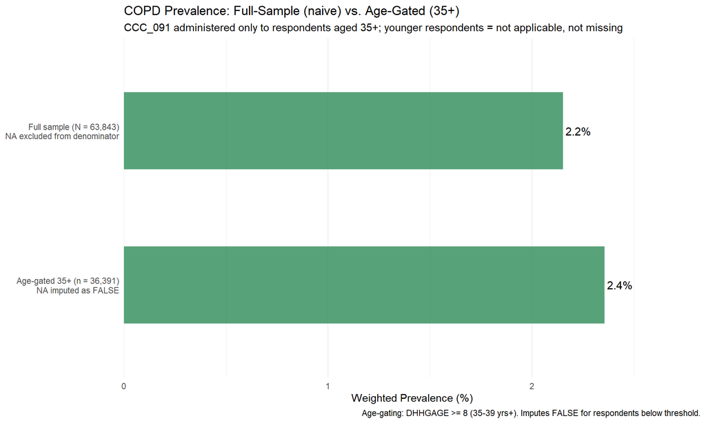

```r
g1a_copd_agegated <- g1a_comparison %>%
  ggplot(aes(x = pct_weighted, y = approach)) +
  geom_col(fill = "#2E8B57", alpha = 0.8, width = 0.5) +
  geom_text(aes(label = sprintf("%.1f%%", pct_weighted)), hjust = -0.1, size = 4) +
  scale_x_continuous(expand = expansion(mult = c(0, 0.2))) +
  labs(
    title    = "COPD Prevalence: Full-Sample (naive) vs. Age-Gated (35+)",
    subtitle = "CCC_091 administered only to respondents aged 35+; younger respondents = not applicable, not missing",
    x = "Weighted Prevalence (%)",
    y = NULL,
    caption  = "Age-gating: DHHGAGE >= 8 (35-39 yrs+). Imputes FALSE for respondents below threshold."
  ) +
  theme_minimal(base_size = 11) +
  theme(panel.grid.major.y = element_blank())
print(g1a_copd_agegated)
```

**COPD prevalence — naive vs age-gated**

```r
ggsave(paste0(prints_folder, "g1a_copd_agegated.png"),
       g1a_copd_agegated, width = 8.5, height = 5.5, dpi = 300)
```

**All 17 conditions — prevalence in 35+ subsample**

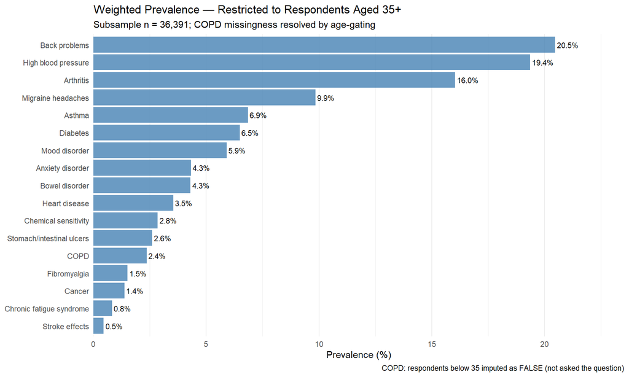

Condition prevalence restricted to respondents aged 35+ (COPD-eligible subsample)

```r
g1a1_prevalence_35plus <- g1a1_data %>%
  ggplot(aes(x = pct_weighted, y = fct_reorder(condition_label, pct_weighted))) +
  geom_col(fill = "#4682B4", alpha = 0.8) +
  geom_text(aes(label = sprintf("%.1f%%", pct_weighted)), hjust = -0.1, size = 3) +
  scale_x_continuous(expand = expansion(mult = c(0, 0.15))) +
  labs(
    title    = "Weighted Prevalence — Restricted to Respondents Aged 35+",
    subtitle = sprintf("Subsample n = %s; COPD missingness resolved by age-gating", format(n_age35plus, big.mark = ",")),
    x = "Prevalence (%)",
    y = NULL,
    caption  = "COPD: respondents below 35 imputed as FALSE (not asked the question)"
  ) +
  theme_minimal(base_size = 11) +
  theme(panel.grid.major.y = element_blank())
print(g1a1_prevalence_35plus)
```

**All 17 conditions — prevalence in 35+ subsample**

```r
ggsave(paste0(prints_folder, "g1a1_prevalence_35plus.png"),
       g1a1_prevalence_35plus, width = 8.5, height = 5.5, dpi = 300)


# ==============================================================================
# G2 FAMILY — Outcome Relationship
# Research question: How does each condition relate to days_absent_total?
# g2  : mean days absent by condition presence (dot plot)
# g21 : median + IQR by condition presence
# g22 : zero-proportion by condition presence
# ==============================================================================
```

## Graph Family G2: Outcome Relationship

**Prepare outcome summaries by condition**

```r
g2_data <- ds_cc_long %>%
  filter(!is.na(has_condition)) %>%
  group_by(condition, condition_label, has_condition) %>%
  summarise(
    n             = n(),
    mean_days     = weighted.mean(days_absent_total, w = .data[[weight_col]], na.rm = TRUE),
    median_days   = median(days_absent_total, na.rm = TRUE),
    q25           = quantile(days_absent_total, 0.25, na.rm = TRUE),
    q75           = quantile(days_absent_total, 0.75, na.rm = TRUE),
    pct_zero      = weighted.mean(days_absent_total == 0, w = .data[[weight_col]], na.rm = TRUE) * 100,
    .groups = "drop"
  )
```

**Mean days absent by condition (those with condition)**

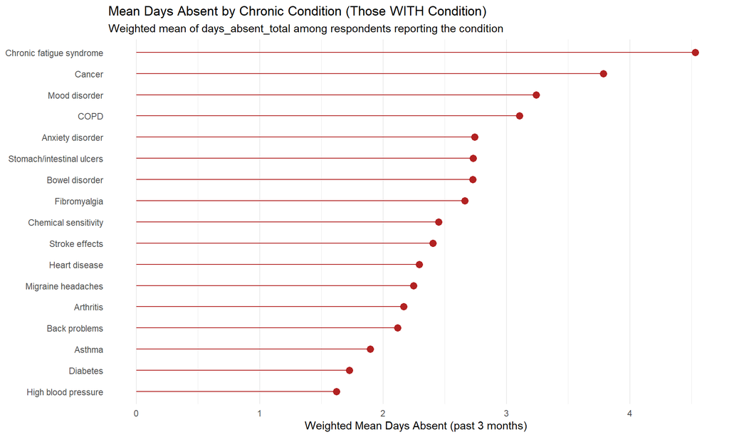

Weighted mean days absent among those reporting each condition

```r
g2_mean_days <- g2_data %>%
  filter(has_condition == TRUE) %>%
  ggplot(aes(x = mean_days, y = fct_reorder(condition_label, mean_days))) +
  geom_point(size = 3, color = "#B22222") +
  geom_segment(aes(xend = 0, yend = condition_label), color = "#B22222", linewidth = 0.5) +
  labs(
    title    = "Mean Days Absent by Chronic Condition (Those WITH Condition)",
    subtitle = "Weighted mean of days_absent_total among respondents reporting the condition",
    x = "Weighted Mean Days Absent (past 3 months)",
    y = NULL
  ) +
  theme_minimal(base_size = 11) +
  theme(panel.grid.major.y = element_blank())
print(g2_mean_days)
```

**Mean days absent by condition (those with condition)**

```r
ggsave(paste0(prints_folder, "g2_mean_days.png"),
       g2_mean_days, width = 8.5, height = 5.5, dpi = 300)
```

**Median days absent (IQR) by condition**

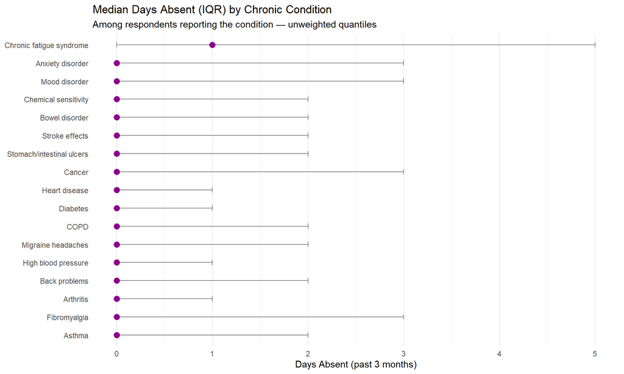

Median and interquartile range of days absent for each condition

```r
g21_median_iqr <- g2_data %>%
  filter(has_condition == TRUE) %>%
  ggplot(aes(y = fct_reorder(condition_label, median_days))) +
  geom_errorbarh(aes(xmin = q25, xmax = q75), height = 0.3, color = "grey50") +
  geom_point(aes(x = median_days), size = 3, color = "#8B008B") +
  labs(
    title    = "Median Days Absent (IQR) by Chronic Condition",
    subtitle = "Among respondents reporting the condition — unweighted quantiles",
    x = "Days Absent (past 3 months)",
    y = NULL
  ) +
  theme_minimal(base_size = 11) +
  theme(panel.grid.major.y = element_blank())
print(g21_median_iqr)
```

**Median days absent (IQR) by condition**

```r
ggsave(paste0(prints_folder, "g21_median_iqr.png"),
       g21_median_iqr, width = 8.5, height = 5.5, dpi = 300)
```

**Zero-day proportion by condition status**

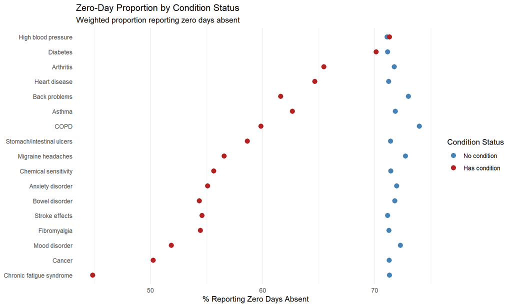

Proportion reporting zero days absent, contrasting condition present vs absent

```r
g22_zero_prop <- g2_data %>%
  ggplot(aes(x = pct_zero, y = fct_reorder(condition_label, pct_zero),
             color = has_condition)) +
  geom_point(size = 3) +
  scale_color_manual(
    values = c("TRUE" = "#B22222", "FALSE" = "#4682B4"),
    labels = c("TRUE" = "Has condition", "FALSE" = "No condition")
  ) +
  labs(
    title    = "Zero-Day Proportion by Condition Status",
    subtitle = "Weighted proportion reporting zero days absent",
    x = "% Reporting Zero Days Absent",
    y = NULL,
    color = "Condition Status"
  ) +
  theme_minimal(base_size = 11) +
  theme(panel.grid.major.y = element_blank())
print(g22_zero_prop)
```

**Zero-day proportion by condition status**

```r
ggsave(paste0(prints_folder, "g22_zero_prop.png"),
       g22_zero_prop, width = 8.5, height = 5.5, dpi = 300)


# ==============================================================================
# G3 FAMILY — Missing Data Profile
# Research question: What is the missing-data pattern across 17 cc_* variables?
# g3  : missingness tile (variable × completeness)
# g31 : missingness by cycle
# ==============================================================================
```

## Graph Family G3: Missing Data Profile

**Compute missingness statistics**

```r
g3_data <- ds0 %>%
  summarise(
    across(all_of(cc_vars), ~ sum(is.na(.x)))
  ) %>%
  pivot_longer(everything(), names_to = "variable", values_to = "n_missing") %>%
  mutate(
    label      = cc_labels[variable],
    pct_missing = n_missing / nrow(ds0) * 100
  ) %>%
  arrange(desc(pct_missing))

g3_by_cycle <- ds0 %>%
  group_by(cchs_cycle_f) %>%
  summarise(
    across(all_of(cc_vars), ~ sum(is.na(.x)) / n() * 100)
  ) %>%
  pivot_longer(-cchs_cycle_f, names_to = "variable", values_to = "pct_missing") %>%
  mutate(label = cc_labels[variable])
```

**Missingness profile across chronic condition variables**

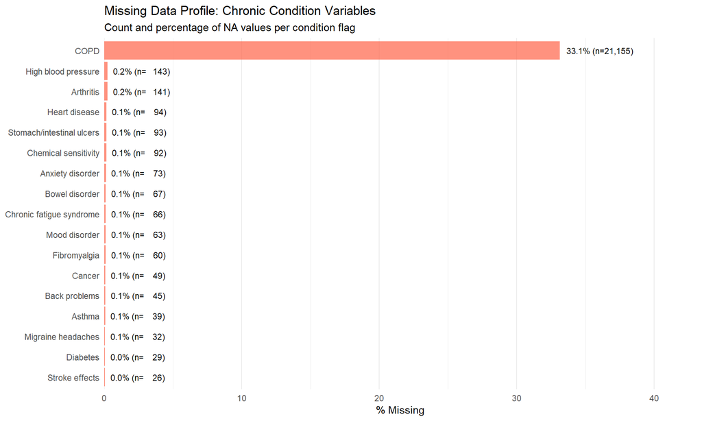

Percentage and count of missing values per condition flag

```r
g3_missing_tile <- g3_data %>%
  ggplot(aes(x = pct_missing, y = fct_reorder(label, pct_missing))) +
  geom_col(fill = "#FF6347", alpha = 0.7) +
  geom_text(aes(label = sprintf("%.1f%% (n=%s)", pct_missing, format(n_missing, big.mark = ","))),
            hjust = -0.1, size = 3) +
  scale_x_continuous(expand = expansion(mult = c(0, 0.3))) +
  labs(
    title    = "Missing Data Profile: Chronic Condition Variables",
    subtitle = "Count and percentage of NA values per condition flag",
    x = "% Missing",
    y = NULL
  ) +
  theme_minimal(base_size = 11) +
  theme(panel.grid.major.y = element_blank())
print(g3_missing_tile)
```

**Missingness profile across chronic condition variables**

```r
ggsave(paste0(prints_folder, "g3_missing_tile.png"),
       g3_missing_tile, width = 8.5, height = 5.5, dpi = 300)
```

**Missingness by CCHS cycle**

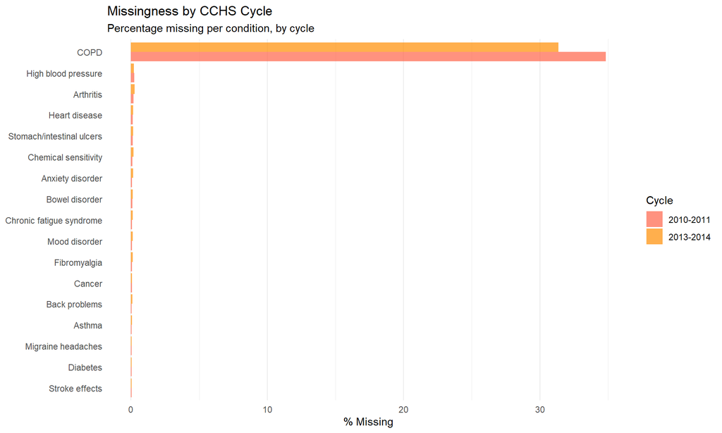

Missing data rates by survey cycle

```r
g31_missing_by_cycle <- g3_by_cycle %>%
  ggplot(aes(x = pct_missing, y = fct_reorder(label, pct_missing),
             fill = cchs_cycle_f)) +
  geom_col(position = "dodge", alpha = 0.7) +
  scale_fill_manual(values = c("2010-2011" = "#FF6347", "2013-2014" = "#FF8C00")) +
  labs(
    title    = "Missingness by CCHS Cycle",
    subtitle = "Percentage missing per condition, by cycle",
    x = "% Missing",
    y = NULL,
    fill = "Cycle"
  ) +
  theme_minimal(base_size = 11) +
  theme(panel.grid.major.y = element_blank())
print(g31_missing_by_cycle)
```

**Missingness by CCHS cycle**

```r
ggsave(paste0(prints_folder, "g31_missing_by_cycle.png"),
       g31_missing_by_cycle, width = 8.5, height = 5.5, dpi = 300)


# ==============================================================================
# G4 FAMILY — Multimorbidity / Co-occurrence
# Research question: What is the multimorbidity structure among respondents?
# g4  : condition-count distribution (bar chart)
# g41 : pairwise co-occurrence matrix (tile heatmap)
# ==============================================================================
```

## Graph Family G4: Multimorbidity / Co-occurrence

**Compute condition counts and co-occurrence matrix**

```r
# Condition count distribution
g4_count_data <- ds_multimorbidity %>%
  group_by(n_conditions) %>%
  summarise(
    n           = n(),
    pct         = n() / nrow(ds_multimorbidity) * 100,
    pct_weighted = sum(.data[[weight_col]]) /
                   sum(ds_multimorbidity[[weight_col]]) * 100,
    .groups = "drop"
  )

# Pairwise co-occurrence matrix (treat NA as FALSE — condition not reported)
cc_matrix <- ds0 %>%
  select(all_of(cc_vars)) %>%
  mutate(across(everything(), ~ as.numeric(coalesce(.x, FALSE))))

n_complete <- nrow(cc_matrix)
co_occurrence <- crossprod(as.matrix(cc_matrix), as.matrix(cc_matrix))
diag(co_occurrence) <- 0
co_occurrence_pct <- co_occurrence / n_complete * 100

# Keep only lower triangle (unique pairs), rank by co-occurrence
g4_cooccur_long <- co_occurrence_pct %>%
  as.data.frame() %>%
  tibble::rownames_to_column("condition_1") %>%
  pivot_longer(-condition_1, names_to = "condition_2", values_to = "pct_cooccur") %>%
  filter(condition_1 < condition_2) %>%
  mutate(
    label_1 = cc_labels[condition_1],
    label_2 = cc_labels[condition_2],
    pair_label = paste0(label_1, " + ", label_2)
  ) %>%
  arrange(desc(pct_cooccur))
```

**Distribution of condition count per respondent**

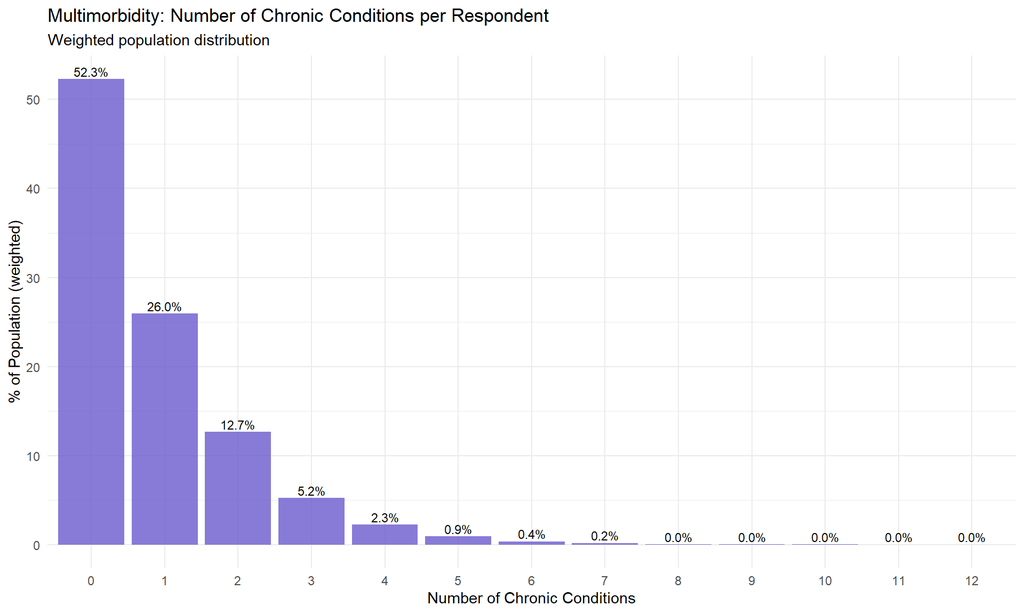

Weighted distribution of number of chronic conditions per respondent

```r
g4_condition_count <- g4_count_data %>%
  ggplot(aes(x = factor(n_conditions), y = pct_weighted)) +
  geom_col(fill = "#6A5ACD", alpha = 0.8) +
  geom_text(aes(label = sprintf("%.1f%%", pct_weighted)), vjust = -0.3, size = 3) +
  labs(
    title    = "Multimorbidity: Number of Chronic Conditions per Respondent",
    subtitle = "Weighted population distribution",
    x = "Number of Chronic Conditions",
    y = "% of Population (weighted)"
  ) +
  theme_minimal(base_size = 11)
print(g4_condition_count)
```

**Distribution of condition count per respondent**

```r
ggsave(paste0(prints_folder, "g4_condition_count.png"),
       g4_condition_count, width = 8.5, height = 5.5, dpi = 300)
```

**Top 20 co-occurring condition pairs (dot plot)**

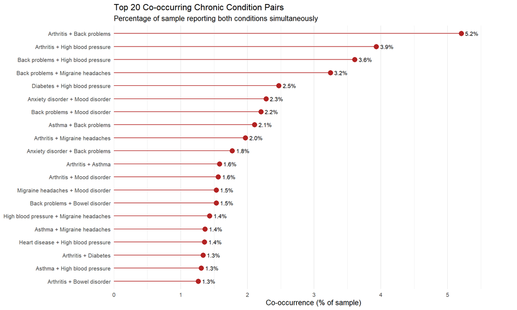

Top 20 condition pairs ranked by co-occurrence rate

```r
# Top 20 co-occurring condition pairs — dot plot ranked by % of sample
g41_top_pairs <- g4_cooccur_long %>%
  slice_head(n = 20) %>%
  mutate(pair_label = fct_reorder(pair_label, pct_cooccur))

g41_cooccurrence <- g41_top_pairs %>%
  ggplot(aes(x = pct_cooccur, y = pair_label)) +
  geom_point(size = 3, color = "#B22222") +
  geom_segment(aes(x = 0, xend = pct_cooccur, yend = pair_label),
               color = "#B22222", linewidth = 0.4) +
  geom_text(aes(label = sprintf("%.1f%%", pct_cooccur)),
            hjust = -0.3, size = 2.8) +
  scale_x_continuous(expand = expansion(mult = c(0, 0.15))) +
  labs(
    title    = "Top 20 Co-occurring Chronic Condition Pairs",
    subtitle = "Percentage of sample reporting both conditions simultaneously",
    x = "Co-occurrence (% of sample)",
    y = NULL
  ) +
  theme_minimal(base_size = 10) +
  theme(panel.grid.major.y = element_blank())
print(g41_cooccurrence)
```

**Top 20 co-occurring condition pairs (dot plot)**

```r
ggsave(paste0(prints_folder, "g41_cooccurrence.png"),
       g41_cooccurrence, width = 8.5, height = 5.5, dpi = 300)

# nolint end
```